# sprint 1and 2

SDS 2206 Data Visualization Analytics and Reporting

PROJECT REPORT Milestones 1 & 2

System - Sports Performance Analytics Visualization System

Milestone 1 (Weeks 1–2) & Milestone 2 (Weeks 3–4)

Dataset- esports dataset.csv (structured tabular data)

Tools- Python 3, Pandas, Matplotlib, NumPy

```python
import os
import pandas as pd
import numpy as np
import matplotlib.pyplot as plt

# --- 1) Load dataset ---
df = pd.read_csv("C:/Users/USER/Downloads/sprint/esports dataset.csv")
```

This report outlines the creation of a Sports Performance Analytics Visualization System using esports data. It follows a six-milestone structure, starting with basic data collection, description, and initial visualization (Milestone 1), then advancing to a structured data processing pipeline for cleaning, transformation, and feature engineering (Milestone 2), preparing the dataset for more advanced analysis and visualization.

```python
# --- 2) Basic info ---
print("Shape (rows, columns):", df.shape)
print("\nColumn types:\n", df.dtypes)
print("\nMissing values per column:\n", df.isna().sum())
print("\nFirst 5 rows:\n", df.head())
```

```
Shape (rows, columns): (2800, 16)

Column types:
 record_id              int64
player_id              int64
team_name             object
player_role           object
map_played            object
match_type            object
kills                  int64
assists                int64
deaths                 int64
accuracy_percent     float64
reaction_time_ms     float64
fatigue_index        float64
performance_score    float64
win_probability      float64
match_outcome         object
mvp_award             object
dtype: object

Missing values per column:
 record_id            0
player_id            0
team_name            0
player_role          0
map_played           0
match_type           0
kills                0
assists              0
deaths               0
accuracy_percent     0
reaction_time_ms     0
fatigue_index        0
performance_score    0
win_probability      0
match_outcome        0
mvp_award            0
dtype: int64

First 5 rows:
    record_id  player_id      team_name player_role    map_played  match_type  \
0          1        160  Titan Esports        Flex    Dust Arena     Playoff
1          2          2  Titan Esports     Support     Neon City       Final
2          3        468     Team Alpha     Support     Neon City  Semi-Final
3          4        447      Team Nova         IGL  Desert Storm       Final
4          5        196  Phantom Squad      Sniper       Skyline     Playoff

   kills  assists  deaths  accuracy_percent  reaction_time_ms  fatigue_index  \
0     18        6       7             40.43            192.28           0.52
1     16        7      11             40.50            201.98           0.68
2     14        7      15             36.93            172.50           0.27
3     12        6      13             53.46            246.83           0.07
4     13        9      13             44.71            266.94           0.52

   performance_score  win_probability match_outcome mvp_award
0              50.02             0.83           Win        No
1              41.45             0.89           Win        No
2              35.77             0.81           Win        No
3              43.03             1.00           Win        No
4              39.16             0.85           Win        No
```

```python
# --- Basic info ---
display(pd.DataFrame({"Rows": [df.shape[0]], "Columns": [df.shape[1]]}).style.hide(axis="index"))

display(df.dtypes.reset_index()
        .rename(columns={"index": "Column", 0: "Data Type"})
        .style.hide(axis="index"))

display(df.isna().sum().reset_index()
        .rename(columns={"index": "Column", 0: "Missing Values"})
        .style.hide(axis="index"))

display(df.head().style.hide(axis="index"))
```

[output not shown]

[output not shown]

[output not shown]

[output not shown]

```python
# --- 3) Cleaning ---
df_clean = df.copy()
```

Creates a copy of the original dataframe so all cleaning steps are applied to `df_clean` without modifying the raw data.

```python
# Remove duplicates
df_clean = df_clean.drop_duplicates()
```

Removes any exact duplicate rows to prevent inflated counts and skewed statistics.

```python
# Standardize string columns
str_cols = ['team_name','player_role','map_played','match_type','match_outcome','mvp_award']
for col in str_cols:
    if col in df_clean.columns:
        df_clean[col] = df_clean[col].astype(str).str.strip().str.lower()
        df_clean[col] = df_clean[col].replace(['', 'none', 'null', 'nan'], np.nan)
```

Converts all categorical columns to lowercase, removes whitespace, and replaces placeholder strings with proper NaN values so labels like "Yes", "yes", and "YES" are treated as identical.

```python
# Convert numeric columns safely
num_cols = ['kills','assists','deaths','accuracy_percent','reaction_time_ms',
            'fatigue_index','performance_score','win_probability']
for col in num_cols:
    if col in df_clean.columns:
        df_clean[col] = pd.to_numeric(df_clean[col], errors='coerce')
```

```python
# Flag impossible ranges (set to NaN)
range_rules = {
    'accuracy_percent': (0, 100),
    'win_probability': (0, 1),
    'fatigue_index': (0, 1),
    'reaction_time_ms': (80, 600),
    'kills': (0, 80),
    'assists': (0, 80),
    'deaths': (0, 80)
}
for col, (lo, hi) in range_rules.items():
    if col in df_clean.columns:
        bad_mask = df_clean[col].notna() & ((df_clean[col] < lo) | (df_clean[col] > hi))
        df_clean.loc[bad_mask, col] = np.nan
```

Defines valid ranges for each numerical column and checks every value against them. Any value that falls outside its allowed range — such as accuracy above 100% or reaction time below 80ms — is replaced with NaN to prevent invalid data from distorting the analysis.

```python
# Replace numeric missing values with 1 (keep object/string missing values as NaN)
numeric_cols = df_clean.select_dtypes(include=[np.number]).columns
if len(numeric_cols) > 0:
    df_clean[numeric_cols] = df_clean[numeric_cols].fillna(1)
```

Finds all numerical columns in the cleaned dataset and replaces any remaining missing values with 1, while leaving categorical columns untouched so their NaN values are preserved for later analysis.

```python
# --- 4) Feature engineering ---
if all(c in df_clean.columns for c in ['kills','assists','deaths']):
    df_clean['kda_ratio'] = (df_clean['kills'] + df_clean['assists']) / df_clean['deaths'].replace(0, np.nan)
    df_clean['kill_death_diff'] = df_clean['kills'] - df_clean['deaths']
```

Creates two new performance features — kda_ratio (kills + assists divided by deaths) to measure overall combat efficiency, and kill_death_diff (kills minus deaths) to show whether a player eliminated more enemies than they lost. Deaths of zero are replaced with NaN to avoid division errors.

```python
# Standardize MVP award values to yes/no and create a binary flag
if 'mvp_award' in df_clean.columns:
    df_clean['mvp_award'] = df_clean['mvp_award'].replace({
        'y': 'yes', 'true': 'yes', '1': 'yes',
        'n': 'no', 'false': 'no', '0': 'no',
        'award': 'yes', 'no award': 'no'
    })
    df_clean.loc[~df_clean['mvp_award'].isin(['yes', 'no']), 'mvp_award'] = np.nan
    df_clean['is_mvp'] = (df_clean['mvp_award'] == 'yes').astype('Int64')
```

Standardizes all MVP award label variants (e.g. 'y', 'true', '1') into a consistent yes/no format, sets any unrecognized values to NaN, then creates a new binary column is_mvp where 1 = awarded and 0 = not awarded.

```python
# --- 5) Save cleaned dataset ---
os.makedirs(os.path.join("data", "processed"), exist_ok=True)
os.makedirs(os.path.join("visuals"), exist_ok=True)
df_clean.to_csv(os.path.join("data", "processed", "cleaned_esports_data.csv"), index=False)
```

Creates the output folders if they don't exist, then saves the cleaned dataset as a CSV file to data/processed/cleaned_esports_data.csv.

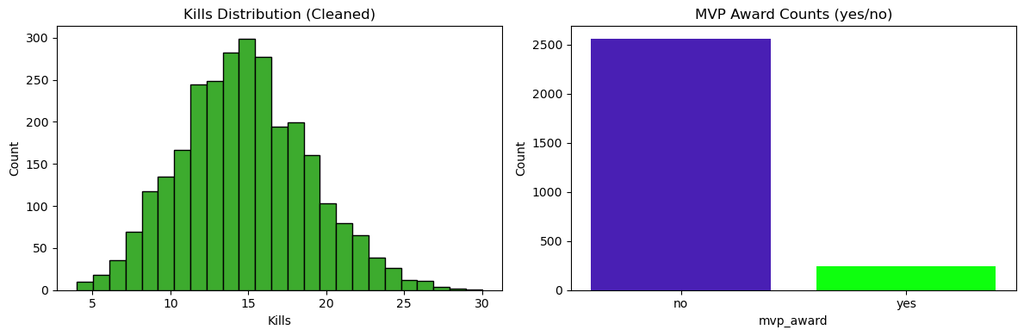

```
Visualization saved to visuals/Kills and MVP Awards.png
```

```python
# --- 6) Visualization ---
fig, axes = plt.subplots(1, 2, figsize=(12, 4))

# Histogram of kills
axes[0].hist(df_clean['kills'].dropna(), bins=25, color="#3DAB2E", edgecolor='black')
axes[0].set_title('Kills Distribution (Cleaned)')
axes[0].set_xlabel('Kills')
axes[0].set_ylabel('Count')

# --- Bar chart of MVP awards (yes vs no) ---
award_counts = df_clean['mvp_award'].value_counts(dropna=False)

axes[1].bar(award_counts.index.astype(str), award_counts.values,
            color=["#491fb4", "#0eff0e"][:len(award_counts)])
axes[1].set_title('MVP Award Counts (yes/no)')
axes[1].set_xlabel('mvp_award')
axes[1].set_ylabel('Count')

plt.tight_layout()
plt.savefig("visuals/Kills and MVP Awards.png")
plt.show()

print("\nVisualization saved to visuals/Kills and MVP Awards.png")
```

The left chart is a histogram showing the distribution of player kills across all matches. The right chart is a bar chart showing the count of MVP award recipients (yes) versus non-recipients (no). The figure is then saved to visuals/Kills and MVP Awards.png and displayed in the notebook.

MILESTONE 2

```python
import os
import pandas as pd
import matplotlib.pyplot as plt

# Create output directories if they don't exist
os.makedirs("visuals", exist_ok=True)
os.makedirs(os.path.join("data", "processed"), exist_ok=True)
```

```python
# --- 1) Load cleaned dataset ---
df = pd.read_csv("data/processed/cleaned_esports_data.csv")
```

```python
# --- 2) Basic descriptive statistics ---
print("\n--- Basic Statistics ---")
print(df.describe(include='all'))   # summary for numeric + categorical
print("\nVariance of numeric columns:\n", df.var(numeric_only=True))
```

```
--- Basic Statistics ---
          record_id    player_id      team_name    player_role map_played  \
count   2800.000000  2800.000000           2800           2800       2800
unique          NaN          NaN              6              5          5
top             NaN          NaN  phantom squad  entry fragger  neon city
freq            NaN          NaN            487            584        576
mean    1400.500000   247.968214            NaN            NaN        NaN
std      808.434702   144.472383            NaN            NaN        NaN
min        1.000000     1.000000            NaN            NaN        NaN
25%      700.750000   121.000000            NaN            NaN        NaN
50%     1400.500000   248.000000            NaN            NaN        NaN
75%     2100.250000   371.000000            NaN            NaN        NaN
max     2800.000000   500.000000            NaN            NaN        NaN

         match_type        kills      assists       deaths  accuracy_percent  \
count          2800  2800.000000  2800.000000  2800.000000       2800.000000
unique            5          NaN          NaN          NaN               NaN
top     group stage          NaN          NaN          NaN               NaN
freq            579          NaN          NaN          NaN               NaN
mean            NaN    14.872500     8.027857    10.025000         45.095225
std             NaN     3.973451     2.843157     3.178069          8.054907
min             NaN     4.000000     0.000000     1.000000         20.460000
25%             NaN    12.000000     6.000000     8.000000         39.542500
50%             NaN    15.000000     8.000000    10.000000         44.960000
75%             NaN    18.000000    10.000000    12.000000         50.552500
max             NaN    30.000000    20.000000    22.000000         71.790000

        reaction_time_ms  fatigue_index  performance_score  win_probability  \
count        2800.000000    2800.000000        2800.000000      2800.000000
unique               NaN            NaN                NaN              NaN
top                  NaN            NaN                NaN              NaN
freq                 NaN            NaN                NaN              NaN
mean          220.129836       0.498875          45.306718         0.916364
std            30.240196       0.291618          10.333504         0.097468
min           118.730000       0.000000          16.580000         0.470000
25%           199.762500       0.240000          38.287500         0.860000
50%           220.685000       0.500000          44.985000         0.950000
75%           240.452500       0.760000          52.302500         1.000000
max           324.110000       1.000000          87.360000         1.000000

```

[output cut: 13 more lines]

```
Variance of numeric columns:
 record_id            653566.666667
player_id             20872.269443
kills                    15.788311
assists                   8.083540
deaths                   10.100125
accuracy_percent         64.881520
reaction_time_ms        914.469440
fatigue_index             0.085041
performance_score       106.781300
win_probability           0.009500
kda_ratio                 1.665976
kill_death_diff          24.709497
is_mvp                    0.078099
dtype: float64
```

```
Kills, Assists, Deaths per Team:
                 kills  assists  deaths
team_name
cyberx         7097.0   3828.0  4727.0
phantom squad  7327.0   3914.0  4834.0
red vortex     7132.0   3865.0  4924.0
team alpha     6896.0   3710.0  4624.0
team nova      6563.0   3548.0  4392.0
titan esports  6628.0   3613.0  4569.0
```

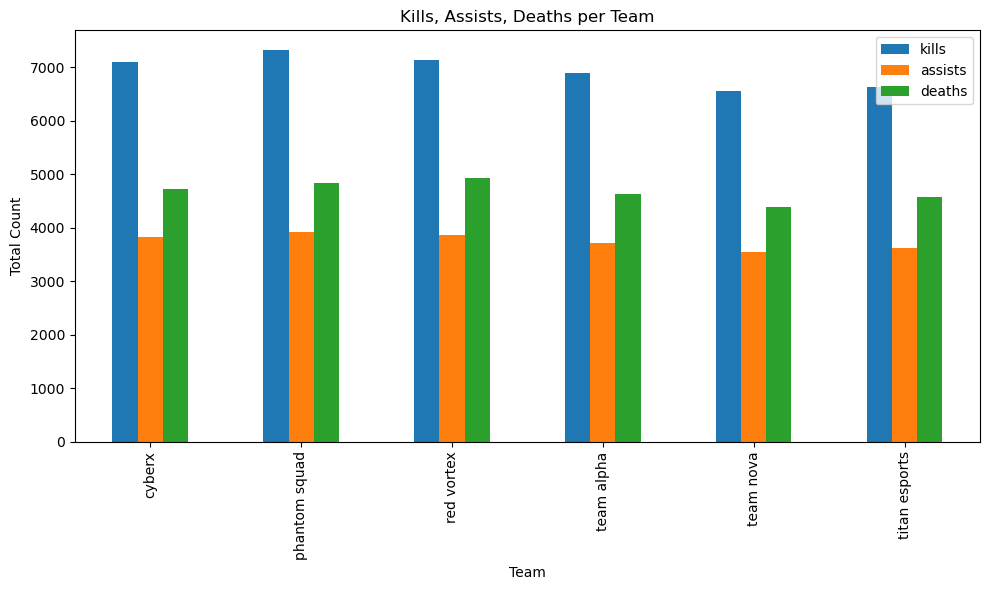

```python
# --- 3) Team-level statistics ---
if 'team_name' in df.columns:
    team_stats = df.groupby('team_name')[['kills','assists','deaths']].sum()
    print("\nKills, Assists, Deaths per Team:\n", team_stats)

    team_stats.plot(kind='bar', figsize=(10,6))
    plt.title("Kills, Assists, Deaths per Team")
    plt.xlabel("Team")
    plt.ylabel("Total Count")
    plt.tight_layout()
    plt.savefig("visuals/team_kills_assists_deaths.png")
    plt.show()
```

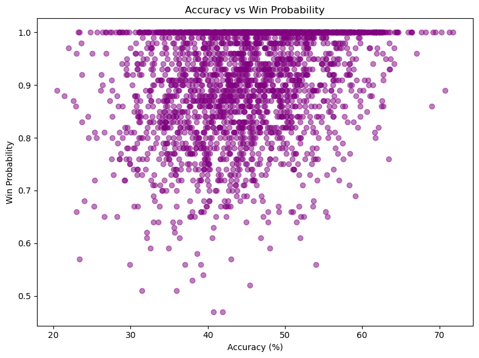

```python
# --- 4) Accuracy vs Win Probability ---
if 'accuracy_percent' in df.columns and 'win_probability' in df.columns:
    plt.figure(figsize=(8,6))
    plt.scatter(df['accuracy_percent'], df['win_probability'], alpha=0.5, color='purple')
    plt.title("Accuracy vs Win Probability")
    plt.xlabel("Accuracy (%)")
    plt.ylabel("Win Probability")
    plt.tight_layout()
    plt.savefig("visuals/accuracy_vs_winprob.png")
    plt.show()
```

```
Player Role Counts:
 player_role
entry fragger    584
igl              569
sniper           558
flex             552
support          537
Name: count, dtype: int64
```

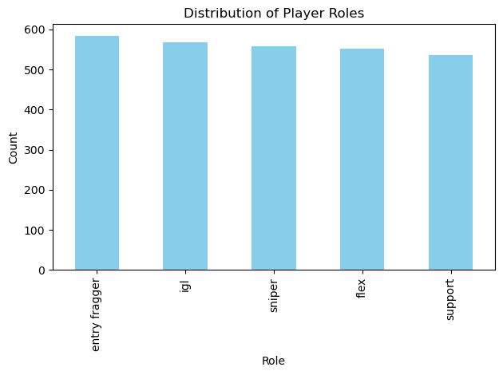

```python
# --- 5) Player Role Analysis ---
if 'player_role' in df.columns:
    role_stats = df['player_role'].value_counts()
    print("\nPlayer Role Counts:\n", role_stats)

    role_stats.plot(kind='bar', color='skyblue')
    plt.title("Distribution of Player Roles")
    plt.xlabel("Role")
    plt.ylabel("Count")
    plt.tight_layout()
    plt.savefig("visuals/player_roles.png")
    plt.show()
```

```
Map Played Counts:
 map_played
neon city       576
dust arena      573
desert storm    571
frozen base     549
skyline         531
Name: count, dtype: int64
```

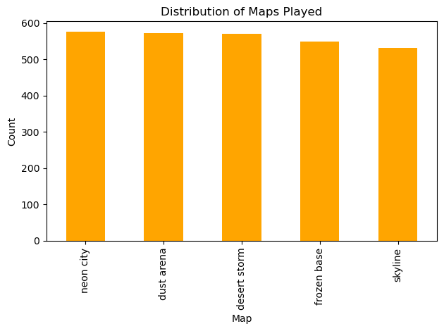

```python
# --- 6) Map Played Analysis ---
if 'map_played' in df.columns:
    map_stats = df['map_played'].value_counts()
    print("\nMap Played Counts:\n", map_stats)

    map_stats.plot(kind='bar', color='orange')
    plt.title("Distribution of Maps Played")
    plt.xlabel("Map")
    plt.ylabel("Count")
    plt.tight_layout()
    plt.savefig("visuals/maps_played.png")
    plt.show()
```

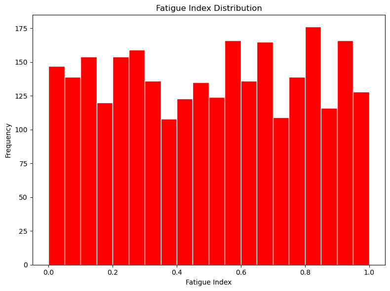

```python
# --- 7) Fatigue Index Analysis ---
if 'fatigue_index' in df.columns:
    plt.figure(figsize=(8,6))
    plt.hist(df['fatigue_index'], bins=20, color='red', edgecolor='white')
    plt.title("Fatigue Index Distribution")
    plt.xlabel("Fatigue Index")
    plt.ylabel("Frequency")
    plt.tight_layout()
    plt.savefig("visuals/fatigue_index_distribution.png")
    plt.show()
```

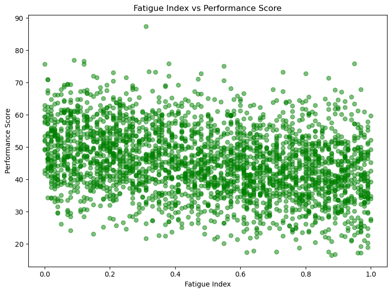

```python
    # Compare fatigue index vs performance score
    if 'performance_score' in df.columns:
        plt.figure(figsize=(8,6))
        plt.scatter(df['fatigue_index'], df['performance_score'], alpha=0.5, color='green')
        plt.title("Fatigue Index vs Performance Score")
        plt.xlabel("Fatigue Index")
        plt.ylabel("Performance Score")
        plt.tight_layout()
        plt.savefig("visuals/fatigue_vs_performance.png")
        plt.show()
```